# Optimal Treatment Analysis

## Outcome Variable

**Outcome Variable:** ever_wasted

## Predictor Variables

**Intervention Variable:** predfeed3

**Adjustment Set:**

- arm
- sex
- month
- brthmon
- W_mage
- meducyrs
- feducyrs
- hhwealth_quart
- hfoodsec
- W_mhtcm
- vagbrth
- W_gagebrth
- W_birthwt
- W_birthlen
- W_nrooms
- W_nchldlt5
- W_parity
- impfloor
- impsan
- safeh20
- delta_W_mage
- delta_meducyrs
- delta_feducyrs
- delta_hhwealth_quart
- delta_hfoodsec
- delta_W_mhtcm
- delta_vagbrth
- delta_W_gagebrth
- delta_W_birthwt
- delta_W_birthlen
- delta_W_nrooms
- delta_W_nchldlt5
- delta_W_parity
- delta_impfloor
- delta_impsan
- delta_safeh20

## Stratifying Variables

The analysis was stratified on these variable(s):

- agecat
- studyid
- country

## Data Summary

| agecat | studyid | country | predfeed3 | ever_wasted | n_cell | n |
| --- | --- | --- | --- | --- | --- | --- |
| 0-24 months (no birth wast) | ki0047075b-MAL-ED | BANGLADESH | 1 | 0 | 162 | 248 |
| 0-24 months (no birth wast) | ki0047075b-MAL-ED | BANGLADESH | 1 | 1 | 51 | 248 |
| 0-24 months (no birth wast) | ki0047075b-MAL-ED | BANGLADESH | 0 | 0 | 31 | 248 |
| 0-24 months (no birth wast) | ki0047075b-MAL-ED | BANGLADESH | 0 | 1 | 4 | 248 |
| 0-24 months (no birth wast) | ki0047075b-MAL-ED | BRAZIL | 1 | 0 | 113 | 224 |
| 0-24 months (no birth wast) | ki0047075b-MAL-ED | BRAZIL | 1 | 1 | 7 | 224 |
| 0-24 months (no birth wast) | ki0047075b-MAL-ED | BRAZIL | 0 | 0 | 99 | 224 |
| 0-24 months (no birth wast) | ki0047075b-MAL-ED | BRAZIL | 0 | 1 | 5 | 224 |
| 0-24 months (no birth wast) | ki0047075b-MAL-ED | INDIA | 1 | 0 | 118 | 235 |
| 0-24 months (no birth wast) | ki0047075b-MAL-ED | INDIA | 1 | 1 | 63 | 235 |
| 0-24 months (no birth wast) | ki0047075b-MAL-ED | INDIA | 0 | 0 | 29 | 235 |
| 0-24 months (no birth wast) | ki0047075b-MAL-ED | INDIA | 0 | 1 | 25 | 235 |
| 0-24 months (no birth wast) | ki0047075b-MAL-ED | NEPAL | 1 | 0 | 105 | 234 |
| 0-24 months (no birth wast) | ki0047075b-MAL-ED | NEPAL | 1 | 1 | 28 | 234 |
| 0-24 months (no birth wast) | ki0047075b-MAL-ED | NEPAL | 0 | 0 | 84 | 234 |
| 0-24 months (no birth wast) | ki0047075b-MAL-ED | NEPAL | 0 | 1 | 17 | 234 |
| 0-24 months (no birth wast) | ki0047075b-MAL-ED | PERU | 1 | 0 | 183 | 286 |
| 0-24 months (no birth wast) | ki0047075b-MAL-ED | PERU | 1 | 1 | 11 | 286 |
| 0-24 months (no birth wast) | ki0047075b-MAL-ED | PERU | 0 | 0 | 84 | 286 |
| 0-24 months (no birth wast) | ki0047075b-MAL-ED | PERU | 0 | 1 | 8 | 286 |
| 0-24 months (no birth wast) | ki0047075b-MAL-ED | SOUTH AFRICA | 1 | 0 | 79 | 275 |
| 0-24 months (no birth wast) | ki0047075b-MAL-ED | SOUTH AFRICA | 1 | 1 | 16 | 275 |
| 0-24 months (no birth wast) | ki0047075b-MAL-ED | SOUTH AFRICA | 0 | 0 | 152 | 275 |
| 0-24 months (no birth wast) | ki0047075b-MAL-ED | SOUTH AFRICA | 0 | 1 | 28 | 275 |
| 0-24 months (no birth wast) | ki0047075b-MAL-ED | TANZANIA, UNITED REPUBLIC OF | 1 | 0 | 83 | 249 |
| 0-24 months (no birth wast) | ki0047075b-MAL-ED | TANZANIA, UNITED REPUBLIC OF | 1 | 1 | 9 | 249 |
| 0-24 months (no birth wast) | ki0047075b-MAL-ED | TANZANIA, UNITED REPUBLIC OF | 0 | 0 | 136 | 249 |
| 0-24 months (no birth wast) | ki0047075b-MAL-ED | TANZANIA, UNITED REPUBLIC OF | 0 | 1 | 21 | 249 |
| 0-24 months (no birth wast) | ki1000109-EE | PAKISTAN | 1 | 0 | 199 | 376 |
| 0-24 months (no birth wast) | ki1000109-EE | PAKISTAN | 1 | 1 | 151 | 376 |

[output cut: 102 more lines]

The following strata were considered:

- agecat: 0-24 months (no birth wast), studyid: ki0047075b-MAL-ED, country: BANGLADESH
- agecat: 0-24 months (no birth wast), studyid: ki0047075b-MAL-ED, country: BRAZIL
- agecat: 0-24 months (no birth wast), studyid: ki0047075b-MAL-ED, country: INDIA
- agecat: 0-24 months (no birth wast), studyid: ki0047075b-MAL-ED, country: NEPAL
- agecat: 0-24 months (no birth wast), studyid: ki0047075b-MAL-ED, country: PERU
- agecat: 0-24 months (no birth wast), studyid: ki0047075b-MAL-ED, country: SOUTH AFRICA
- agecat: 0-24 months (no birth wast), studyid: ki0047075b-MAL-ED, country: TANZANIA, UNITED REPUBLIC OF
- agecat: 0-24 months (no birth wast), studyid: ki1000109-EE, country: PAKISTAN
- agecat: 0-24 months (no birth wast), studyid: ki1113344-GMS-Nepal, country: NEPAL
- agecat: 0-24 months (no birth wast), studyid: kiGH5241-JiVitA-3, country: BANGLADESH
- agecat: 0-24 months (no birth wast), studyid: kiGH5241-JiVitA-4, country: BANGLADESH
- agecat: 0-6 months (no birth wast), studyid: ki0047075b-MAL-ED, country: BANGLADESH
- agecat: 0-6 months (no birth wast), studyid: ki0047075b-MAL-ED, country: BRAZIL
- agecat: 0-6 months (no birth wast), studyid: ki0047075b-MAL-ED, country: INDIA
- agecat: 0-6 months (no birth wast), studyid: ki0047075b-MAL-ED, country: NEPAL
- agecat: 0-6 months (no birth wast), studyid: ki0047075b-MAL-ED, country: PERU
- agecat: 0-6 months (no birth wast), studyid: ki0047075b-MAL-ED, country: SOUTH AFRICA
- agecat: 0-6 months (no birth wast), studyid: ki0047075b-MAL-ED, country: TANZANIA, UNITED REPUBLIC OF
- agecat: 0-6 months (no birth wast), studyid: ki1000109-EE, country: PAKISTAN
- agecat: 0-6 months (no birth wast), studyid: ki1113344-GMS-Nepal, country: NEPAL
- agecat: 0-6 months (no birth wast), studyid: kiGH5241-JiVitA-3, country: BANGLADESH
- agecat: 0-6 months (no birth wast), studyid: kiGH5241-JiVitA-4, country: BANGLADESH
- agecat: 6-24 months, studyid: ki0047075b-MAL-ED, country: BANGLADESH
- agecat: 6-24 months, studyid: ki0047075b-MAL-ED, country: BRAZIL
- agecat: 6-24 months, studyid: ki0047075b-MAL-ED, country: INDIA
- agecat: 6-24 months, studyid: ki0047075b-MAL-ED, country: NEPAL
- agecat: 6-24 months, studyid: ki0047075b-MAL-ED, country: PERU
- agecat: 6-24 months, studyid: ki0047075b-MAL-ED, country: SOUTH AFRICA
- agecat: 6-24 months, studyid: ki0047075b-MAL-ED, country: TANZANIA, UNITED REPUBLIC OF
- agecat: 6-24 months, studyid: ki1000109-EE, country: PAKISTAN
- agecat: 6-24 months, studyid: ki1113344-GMS-Nepal, country: NEPAL
- agecat: 6-24 months, studyid: kiGH5241-JiVitA-3, country: BANGLADESH
- agecat: 6-24 months, studyid: kiGH5241-JiVitA-4, country: BANGLADESH

### Dropped Strata

Some strata were dropped due to rare outcomes:

- agecat: 0-24 months (no birth wast), studyid: ki0047075b-MAL-ED, country: BANGLADESH
- agecat: 0-24 months (no birth wast), studyid: kiGH5241-JiVitA-4, country: BANGLADESH
- agecat: 0-6 months (no birth wast), studyid: ki0047075b-MAL-ED, country: BANGLADESH
- agecat: 0-6 months (no birth wast), studyid: ki0047075b-MAL-ED, country: BRAZIL
- agecat: 0-6 months (no birth wast), studyid: ki0047075b-MAL-ED, country: PERU
- agecat: 0-6 months (no birth wast), studyid: ki0047075b-MAL-ED, country: TANZANIA, UNITED REPUBLIC OF
- agecat: 0-6 months (no birth wast), studyid: kiGH5241-JiVitA-4, country: BANGLADESH
- agecat: 6-24 months, studyid: ki0047075b-MAL-ED, country: BANGLADESH
- agecat: 6-24 months, studyid: ki0047075b-MAL-ED, country: BRAZIL
- agecat: 6-24 months, studyid: kiGH5241-JiVitA-4, country: BANGLADESH

## Methods Detail

We’re interested in the causal parameters $E[Y_a]$ for all values of $a \in \mathcal{A}$. These parameters represent the mean outcome if, possibly contrary to fact, we intervened to set all units to have $A=a$. Under the randomization and positivity assumptions, these are identified by the statistical parameters $\psi_a=E_W[E_{Y|A,W}(Y|A=a,W)]$. In addition, we’re interested in the mean of $Y$, $E[Y]$ under no intervention (the observed mean). We will estimate these parameters by using SuperLearner to fit the relevant likelihood factors – $E_{Y|A,W}(Y|A=a,W)$ and $p(A=a|W)$, and then updating our likelihood fit using a joint TMLE.

For unadjusted analyses ($W=\{\}$), initial likelihoods were estimated using Lrnr_glm to estimate the simple $E(Y|A)$ and Lrnr_mean to estimate $p(A)$. For adjusted analyses, a small library containing Lrnr_glmnet, Lrnr_xgboost, and Lrnr_mean was used.

Having estimated these parameters, we will then use the delta method to estimate relative risks and attributable risks relative to a prespecified baseline level of $A$.

# Results Detail

## Results Plots

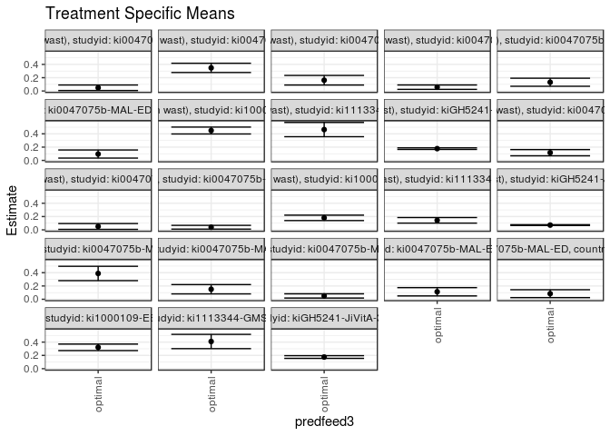

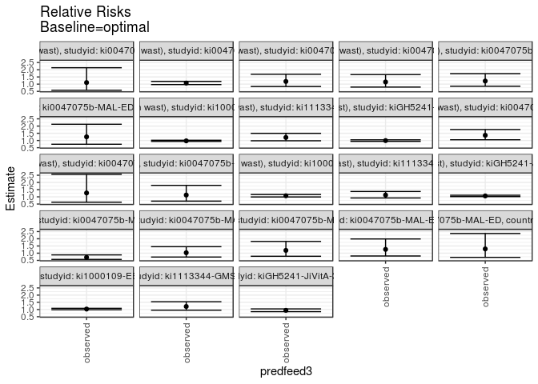

## Results Table

### Parameter: TSM

| agecat | studyid | country | intervention_level | baseline_level | estimate | ci_lower | ci_upper |
| --- | --- | --- | --- | --- | --- | --- | --- |
| 0-24 months (no birth wast) | ki0047075b-MAL-ED | BRAZIL | optimal | NA | 0.0483279 | 0.0066621 | 0.0899936 |
| 0-24 months (no birth wast) | ki0047075b-MAL-ED | INDIA | optimal | NA | 0.3479669 | 0.2782860 | 0.4176477 |
| 0-24 months (no birth wast) | ki0047075b-MAL-ED | NEPAL | optimal | NA | 0.1619393 | 0.0898381 | 0.2340405 |
| 0-24 months (no birth wast) | ki0047075b-MAL-ED | PERU | optimal | NA | 0.0577183 | 0.0247314 | 0.0907051 |
| 0-24 months (no birth wast) | ki0047075b-MAL-ED | SOUTH AFRICA | optimal | NA | 0.1316800 | 0.0708948 | 0.1924652 |
| 0-24 months (no birth wast) | ki0047075b-MAL-ED | TANZANIA, UNITED REPUBLIC OF | optimal | NA | 0.0960691 | 0.0351616 | 0.1569765 |
| 0-24 months (no birth wast) | ki1000109-EE | PAKISTAN | optimal | NA | 0.4498856 | 0.3976912 | 0.5020801 |
| 0-24 months (no birth wast) | ki1113344-GMS-Nepal | NEPAL | optimal | NA | 0.4642095 | 0.3568569 | 0.5715622 |
| 0-24 months (no birth wast) | kiGH5241-JiVitA-3 | BANGLADESH | optimal | NA | 0.1770750 | 0.1651200 | 0.1890300 |
| 0-6 months (no birth wast) | ki0047075b-MAL-ED | INDIA | optimal | NA | 0.1162461 | 0.0692723 | 0.1632199 |
| 0-6 months (no birth wast) | ki0047075b-MAL-ED | NEPAL | optimal | NA | 0.0509848 | 0.0070649 | 0.0949048 |
| 0-6 months (no birth wast) | ki0047075b-MAL-ED | SOUTH AFRICA | optimal | NA | 0.0389705 | 0.0105632 | 0.0673779 |
| 0-6 months (no birth wast) | ki1000109-EE | PAKISTAN | optimal | NA | 0.1803392 | 0.1396010 | 0.2210774 |
| 0-6 months (no birth wast) | ki1113344-GMS-Nepal | NEPAL | optimal | NA | 0.1431415 | 0.1011735 | 0.1851095 |
| 0-6 months (no birth wast) | kiGH5241-JiVitA-3 | BANGLADESH | optimal | NA | 0.0713844 | 0.0652233 | 0.0775454 |
| 6-24 months | ki0047075b-MAL-ED | INDIA | optimal | NA | 0.3882415 | 0.2801756 | 0.4963074 |
| 6-24 months | ki0047075b-MAL-ED | NEPAL | optimal | NA | 0.1505241 | 0.0802821 | 0.2207661 |
| 6-24 months | ki0047075b-MAL-ED | PERU | optimal | NA | 0.0499952 | 0.0181333 | 0.0818572 |
| 6-24 months | ki0047075b-MAL-ED | SOUTH AFRICA | optimal | NA | 0.1125424 | 0.0500925 | 0.1749923 |
| 6-24 months | ki0047075b-MAL-ED | TANZANIA, UNITED REPUBLIC OF | optimal | NA | 0.0839674 | 0.0245075 | 0.1434273 |
| 6-24 months | ki1000109-EE | PAKISTAN | optimal | NA | 0.3213558 | 0.2721900 | 0.3705216 |
| 6-24 months | ki1113344-GMS-Nepal | NEPAL | optimal | NA | 0.4092525 | 0.3017172 | 0.5167878 |
| 6-24 months | kiGH5241-JiVitA-3 | BANGLADESH | optimal | NA | 0.1756710 | 0.1553405 | 0.1960015 |

### Parameter: E(Y)

| agecat | studyid | country | intervention_level | baseline_level | estimate | ci_lower | ci_upper |
| --- | --- | --- | --- | --- | --- | --- | --- |
| 0-24 months (no birth wast) | ki0047075b-MAL-ED | BRAZIL | observed | NA | 0.0535714 | 0.0240181 | 0.0831247 |
| 0-24 months (no birth wast) | ki0047075b-MAL-ED | INDIA | observed | NA | 0.3744681 | 0.3124566 | 0.4364796 |
| 0-24 months (no birth wast) | ki0047075b-MAL-ED | NEPAL | observed | NA | 0.1923077 | 0.1417029 | 0.2429125 |
| 0-24 months (no birth wast) | ki0047075b-MAL-ED | PERU | observed | NA | 0.0664336 | 0.0375206 | 0.0953465 |
| 0-24 months (no birth wast) | ki0047075b-MAL-ED | SOUTH AFRICA | observed | NA | 0.1600000 | 0.1165917 | 0.2034083 |
| 0-24 months (no birth wast) | ki0047075b-MAL-ED | TANZANIA, UNITED REPUBLIC OF | observed | NA | 0.1204819 | 0.0799679 | 0.1609960 |
| 0-24 months (no birth wast) | ki1000109-EE | PAKISTAN | observed | NA | 0.4388298 | 0.3886039 | 0.4890557 |
| 0-24 months (no birth wast) | ki1113344-GMS-Nepal | NEPAL | observed | NA | 0.5622318 | 0.5171396 | 0.6073240 |
| 0-24 months (no birth wast) | kiGH5241-JiVitA-3 | BANGLADESH | observed | NA | 0.1758810 | 0.1679189 | 0.1838431 |
| 0-6 months (no birth wast) | ki0047075b-MAL-ED | INDIA | observed | NA | 0.1581197 | 0.1112720 | 0.2049674 |
| 0-6 months (no birth wast) | ki0047075b-MAL-ED | NEPAL | observed | NA | 0.0646552 | 0.0329427 | 0.0963676 |
| 0-6 months (no birth wast) | ki0047075b-MAL-ED | SOUTH AFRICA | observed | NA | 0.0437956 | 0.0195207 | 0.0680705 |
| 0-6 months (no birth wast) | ki1000109-EE | PAKISTAN | observed | NA | 0.1935484 | 0.1533466 | 0.2337501 |
| 0-6 months (no birth wast) | ki1113344-GMS-Nepal | NEPAL | observed | NA | 0.1607143 | 0.1266675 | 0.1947611 |
| 0-6 months (no birth wast) | kiGH5241-JiVitA-3 | BANGLADESH | observed | NA | 0.0758803 | 0.0704341 | 0.0813266 |
| 6-24 months | ki0047075b-MAL-ED | INDIA | observed | NA | 0.2746781 | 0.2172425 | 0.3321138 |
| 6-24 months | ki0047075b-MAL-ED | NEPAL | observed | NA | 0.1551724 | 0.1084814 | 0.2018634 |
| 6-24 months | ki0047075b-MAL-ED | PERU | observed | NA | 0.0597015 | 0.0312819 | 0.0881211 |
| 6-24 months | ki0047075b-MAL-ED | SOUTH AFRICA | observed | NA | 0.1422925 | 0.0991596 | 0.1854254 |
| 6-24 months | ki0047075b-MAL-ED | TANZANIA, UNITED REPUBLIC OF | observed | NA | 0.1087866 | 0.0692283 | 0.1483450 |
| 6-24 months | ki1000109-EE | PAKISTAN | observed | NA | 0.3315508 | 0.2837756 | 0.3793260 |
| 6-24 months | ki1113344-GMS-Nepal | NEPAL | observed | NA | 0.4957265 | 0.4503800 | 0.5410730 |
| 6-24 months | kiGH5241-JiVitA-3 | BANGLADESH | observed | NA | 0.1657825 | 0.1564932 | 0.1750718 |

### Parameter: RR

| agecat | studyid | country | intervention_level | baseline_level | estimate | ci_lower | ci_upper |
| --- | --- | --- | --- | --- | --- | --- | --- |
| 0-24 months (no birth wast) | ki0047075b-MAL-ED | BRAZIL | observed | optimal | 1.1084998 | 0.5743827 | 2.1392912 |
| 0-24 months (no birth wast) | ki0047075b-MAL-ED | INDIA | observed | optimal | 1.0761602 | 0.9722564 | 1.1911680 |
| 0-24 months (no birth wast) | ki0047075b-MAL-ED | NEPAL | observed | optimal | 1.1875296 | 0.8363487 | 1.6861707 |
| 0-24 months (no birth wast) | ki0047075b-MAL-ED | PERU | observed | optimal | 1.1509972 | 0.7960192 | 1.6642746 |
| 0-24 months (no birth wast) | ki0047075b-MAL-ED | SOUTH AFRICA | observed | optimal | 1.2150670 | 0.8545446 | 1.7276897 |
| 0-24 months (no birth wast) | ki0047075b-MAL-ED | TANZANIA, UNITED REPUBLIC OF | observed | optimal | 1.2541177 | 0.7397214 | 2.1262212 |
| 0-24 months (no birth wast) | ki1000109-EE | PAKISTAN | observed | optimal | 0.9754252 | 0.9364966 | 1.0159720 |
| 0-24 months (no birth wast) | ki1113344-GMS-Nepal | NEPAL | observed | optimal | 1.2111594 | 0.9804935 | 1.4960906 |
| 0-24 months (no birth wast) | kiGH5241-JiVitA-3 | BANGLADESH | observed | optimal | 0.9932571 | 0.9420882 | 1.0472051 |
| 0-6 months (no birth wast) | ki0047075b-MAL-ED | INDIA | observed | optimal | 1.3602147 | 1.0508290 | 1.7606899 |
| 0-6 months (no birth wast) | ki0047075b-MAL-ED | NEPAL | observed | optimal | 1.2681254 | 0.6285313 | 2.5585712 |
| 0-6 months (no birth wast) | ki0047075b-MAL-ED | SOUTH AFRICA | observed | optimal | 1.1238133 | 0.7029809 | 1.7965729 |
| 0-6 months (no birth wast) | ki1000109-EE | PAKISTAN | observed | optimal | 1.0732464 | 0.9913771 | 1.1618765 |
| 0-6 months (no birth wast) | ki1113344-GMS-Nepal | NEPAL | observed | optimal | 1.1227652 | 0.9203755 | 1.3696604 |
| 0-6 months (no birth wast) | kiGH5241-JiVitA-3 | BANGLADESH | observed | optimal | 1.0629824 | 1.0172367 | 1.1107852 |
| 6-24 months | ki0047075b-MAL-ED | INDIA | observed | optimal | 0.7074929 | 0.5688024 | 0.8800002 |
| 6-24 months | ki0047075b-MAL-ED | NEPAL | observed | optimal | 1.0308806 | 0.7327356 | 1.4503387 |
| 6-24 months | ki0047075b-MAL-ED | PERU | observed | optimal | 1.1941444 | 0.7853651 | 1.8156915 |
| 6-24 months | ki0047075b-MAL-ED | SOUTH AFRICA | observed | optimal | 1.2643453 | 0.8043780 | 1.9873356 |
| 6-24 months | ki0047075b-MAL-ED | TANZANIA, UNITED REPUBLIC OF | observed | optimal | 1.2955821 | 0.7093587 | 2.3662683 |
| 6-24 months | ki1000109-EE | PAKISTAN | observed | optimal | 1.0317249 | 0.9828887 | 1.0829877 |
| 6-24 months | ki1113344-GMS-Nepal | NEPAL | observed | optimal | 1.2112975 | 0.9525175 | 1.5403828 |
| 6-24 months | kiGH5241-JiVitA-3 | BANGLADESH | observed | optimal | 0.9437102 | 0.8521825 | 1.0450684 |

### Parameter: PAR

| agecat | studyid | country | intervention_level | baseline_level | estimate | ci_lower | ci_upper |
| --- | --- | --- | --- | --- | --- | --- | --- |
| 0-24 months (no birth wast) | ki0047075b-MAL-ED | BRAZIL | optimal | NA | 0.0052436 | -0.0266352 | 0.0371223 |
| 0-24 months (no birth wast) | ki0047075b-MAL-ED | INDIA | optimal | NA | 0.0265012 | -0.0087931 | 0.0617955 |
| 0-24 months (no birth wast) | ki0047075b-MAL-ED | NEPAL | optimal | NA | 0.0303684 | -0.0267033 | 0.0874402 |
| 0-24 months (no birth wast) | ki0047075b-MAL-ED | PERU | optimal | NA | 0.0087153 | -0.0128899 | 0.0303205 |
| 0-24 months (no birth wast) | ki0047075b-MAL-ED | SOUTH AFRICA | optimal | NA | 0.0283200 | -0.0180392 | 0.0746792 |
| 0-24 months (no birth wast) | ki0047075b-MAL-ED | TANZANIA, UNITED REPUBLIC OF | optimal | NA | 0.0244129 | -0.0267305 | 0.0755562 |
| 0-24 months (no birth wast) | ki1000109-EE | PAKISTAN | optimal | NA | -0.0110559 | -0.0292456 | 0.0071339 |
| 0-24 months (no birth wast) | ki1113344-GMS-Nepal | NEPAL | optimal | NA | 0.0980222 | 0.0001896 | 0.1958548 |
| 0-24 months (no birth wast) | kiGH5241-JiVitA-3 | BANGLADESH | optimal | NA | -0.0011940 | -0.0105565 | 0.0081685 |
| 0-6 months (no birth wast) | ki0047075b-MAL-ED | INDIA | optimal | NA | 0.0418736 | 0.0100855 | 0.0736616 |
| 0-6 months (no birth wast) | ki0047075b-MAL-ED | NEPAL | optimal | NA | 0.0136703 | -0.0226547 | 0.0499953 |
| 0-6 months (no birth wast) | ki0047075b-MAL-ED | SOUTH AFRICA | optimal | NA | 0.0048251 | -0.0136321 | 0.0232823 |
| 0-6 months (no birth wast) | ki1000109-EE | PAKISTAN | optimal | NA | 0.0132092 | -0.0012305 | 0.0276489 |
| 0-6 months (no birth wast) | ki1113344-GMS-Nepal | NEPAL | optimal | NA | 0.0175728 | -0.0110526 | 0.0461982 |
| 0-6 months (no birth wast) | kiGH5241-JiVitA-3 | BANGLADESH | optimal | NA | 0.0044960 | 0.0013578 | 0.0076341 |
| 6-24 months | ki0047075b-MAL-ED | INDIA | optimal | NA | -0.1135634 | -0.1979977 | -0.0291290 |
| 6-24 months | ki0047075b-MAL-ED | NEPAL | optimal | NA | 0.0046483 | -0.0466845 | 0.0559811 |
| 6-24 months | ki0047075b-MAL-ED | PERU | optimal | NA | 0.0097063 | -0.0117022 | 0.0311148 |
| 6-24 months | ki0047075b-MAL-ED | SOUTH AFRICA | optimal | NA | 0.0297501 | -0.0215649 | 0.0810650 |
| 6-24 months | ki0047075b-MAL-ED | TANZANIA, UNITED REPUBLIC OF | optimal | NA | 0.0248192 | -0.0264280 | 0.0760665 |
| 6-24 months | ki1000109-EE | PAKISTAN | optimal | NA | 0.0101950 | -0.0054265 | 0.0258165 |
| 6-24 months | ki1113344-GMS-Nepal | NEPAL | optimal | NA | 0.0864740 | -0.0116792 | 0.1846272 |
| 6-24 months | kiGH5241-JiVitA-3 | BANGLADESH | optimal | NA | -0.0098885 | -0.0278113 | 0.0080343 |

### Parameter: PAF

| agecat | studyid | country | intervention_level | baseline_level | estimate | ci_lower | ci_upper |
| --- | --- | --- | --- | --- | --- | --- | --- |
| 0-24 months (no birth wast) | ki0047075b-MAL-ED | BRAZIL | optimal | NA | 0.0978799 | -0.7409995 | 0.5325555 |
| 0-24 months (no birth wast) | ki0047075b-MAL-ED | INDIA | optimal | NA | 0.0707703 | -0.0285353 | 0.1604879 |
| 0-24 months (no birth wast) | ki0047075b-MAL-ED | NEPAL | optimal | NA | 0.1579158 | -0.1956735 | 0.4069402 |
| 0-24 months (no birth wast) | ki0047075b-MAL-ED | PERU | optimal | NA | 0.1311881 | -0.2562511 | 0.3991376 |
| 0-24 months (no birth wast) | ki0047075b-MAL-ED | SOUTH AFRICA | optimal | NA | 0.1770001 | -0.1702140 | 0.4211924 |
| 0-24 months (no birth wast) | ki0047075b-MAL-ED | TANZANIA, UNITED REPUBLIC OF | optimal | NA | 0.2026267 | -0.3518603 | 0.5296821 |
| 0-24 months (no birth wast) | ki1000109-EE | PAKISTAN | optimal | NA | -0.0251939 | -0.0678095 | 0.0157209 |
| 0-24 months (no birth wast) | ki1113344-GMS-Nepal | NEPAL | optimal | NA | 0.1743449 | -0.0198946 | 0.3315913 |
| 0-24 months (no birth wast) | kiGH5241-JiVitA-3 | BANGLADESH | optimal | NA | -0.0067887 | -0.0614717 | 0.0450772 |
| 0-6 months (no birth wast) | ki0047075b-MAL-ED | INDIA | optimal | NA | 0.2648219 | 0.0483704 | 0.4320408 |
| 0-6 months (no birth wast) | ki0047075b-MAL-ED | NEPAL | optimal | NA | 0.2114345 | -0.5910107 | 0.6091569 |
| 0-6 months (no birth wast) | ki0047075b-MAL-ED | SOUTH AFRICA | optimal | NA | 0.1101725 | -0.4225139 | 0.4433847 |
| 0-6 months (no birth wast) | ki1000109-EE | PAKISTAN | optimal | NA | 0.0682475 | -0.0086979 | 0.1393233 |
| 0-6 months (no birth wast) | ki1113344-GMS-Nepal | NEPAL | optimal | NA | 0.1093419 | -0.0865131 | 0.2698920 |
| 0-6 months (no birth wast) | kiGH5241-JiVitA-3 | BANGLADESH | optimal | NA | 0.0592506 | 0.0169447 | 0.0997359 |
| 6-24 months | ki0047075b-MAL-ED | INDIA | optimal | NA | -0.4134417 | -0.7580797 | -0.1363634 |
| 6-24 months | ki0047075b-MAL-ED | NEPAL | optimal | NA | 0.0299555 | -0.3647488 | 0.3105059 |
| 6-24 months | ki0047075b-MAL-ED | PERU | optimal | NA | 0.1625803 | -0.2732931 | 0.4492457 |
| 6-24 months | ki0047075b-MAL-ED | SOUTH AFRICA | optimal | NA | 0.2090768 | -0.2431966 | 0.4968137 |
| 6-24 months | ki0047075b-MAL-ED | TANZANIA, UNITED REPUBLIC OF | optimal | NA | 0.2281462 | -0.4097241 | 0.5773937 |
| 6-24 months | ki1000109-EE | PAKISTAN | optimal | NA | 0.0307494 | -0.0174092 | 0.0766285 |
| 6-24 months | ki1113344-GMS-Nepal | NEPAL | optimal | NA | 0.1744389 | -0.0498495 | 0.3508107 |
| 6-24 months | kiGH5241-JiVitA-3 | BANGLADESH | optimal | NA | -0.0596473 | -0.1734576 | 0.0431248 |